# CMSC320 Project 2: Moneyball

# Name: Zijie Cai

# UID: 117081794

# Part 1: Wrangling

# Problem 1: Using SQL compute a relation containing the total payroll and winning percentage (number of wins / number of games * 100) for each team (that is, for each teamID and yearID combination).

```python
# Python packages for (sqlite) data access and extraction
import sqlite3 as sql
import pandas as pd

# Read the sqlite file and establish a sql connection
sqlite_file = "lahman2014.sqlite"
conn = sql.connect(sqlite_file)

# Extract the desired columns from the Salaries table and store a new column with the sum of total payroll grouped by each team and year
salary_query = "SELECT teamID, yearID, sum(salary) as total_payroll FROM Salaries GROUP BY teamID, yearID"

# Read the salary_query into a pandas dataframe
team_salaries = pd.read_sql(salary_query, conn)

# Extract the desired columns from the Teams table and calculate the winning percentage grouped by each team and year and store it in a new column
winnings_query = "SELECT teamID, yearID, franchID as franchiseID, W as wins, G as games, (W/(G*1.0)*100) as winning_percentage FROM Teams GROUP BY teamID, yearID"

# Read the winnings_query into a pandas dataframe
team_winnings = pd.read_sql(winnings_query, conn)

# Merge the two dataframes by left join on teamID and yearID on the Salaries table
salaries_winnings = pd.merge(team_salaries, team_winnings, on=["teamID", "yearID"])

# Visualization
salaries_winnings
```

|  | teamID | yearID | total_payroll | franchiseID | wins | games | winning_percentage |
| --- | --- | --- | --- | --- | --- | --- | --- |
| 0 | ATL | 1985 | 14807000.0 | ATL | 66 | 162 | 40.740741 |
| 1 | BAL | 1985 | 11560712.0 | BAL | 83 | 161 | 51.552795 |
| 2 | BOS | 1985 | 10897560.0 | BOS | 81 | 163 | 49.693252 |
| 3 | CAL | 1985 | 14427894.0 | ANA | 90 | 162 | 55.555556 |
| 4 | CHA | 1985 | 9846178.0 | CHW | 85 | 163 | 52.147239 |
| 5 | CHN | 1985 | 12702917.0 | CHC | 77 | 162 | 47.530864 |
| 6 | CIN | 1985 | 8359917.0 | CIN | 89 | 162 | 54.938272 |
| 7 | CLE | 1985 | 6551666.0 | CLE | 60 | 162 | 37.037037 |
| 8 | DET | 1985 | 10348143.0 | DET | 84 | 161 | 52.173913 |
| 9 | HOU | 1985 | 9993051.0 | HOU | 83 | 162 | 51.234568 |
| 10 | KCA | 1985 | 9321179.0 | KCR | 91 | 162 | 56.172840 |
| 11 | LAN | 1985 | 10967917.0 | LAD | 95 | 162 | 58.641975 |
| 12 | MIN | 1985 | 5764821.0 | MIN | 77 | 162 | 47.530864 |
| 13 | ML4 | 1985 | 11284107.0 | MIL | 71 | 161 | 44.099379 |
| 14 | MON | 1985 | 9470166.0 | WSN | 84 | 161 | 52.173913 |
| 15 | NYA | 1985 | 14238204.0 | NYY | 97 | 161 | 60.248447 |
| 16 | NYN | 1985 | 10834762.0 | NYM | 98 | 162 | 60.493827 |
| 17 | OAK | 1985 | 9058606.0 | OAK | 77 | 162 | 47.530864 |
| 18 | PHI | 1985 | 10124966.0 | PHI | 75 | 162 | 46.296296 |
| 19 | PIT | 1985 | 9227500.0 | PIT | 57 | 161 | 35.403727 |
| 20 | SDN | 1985 | 11036583.0 | SDP | 83 | 162 | 51.234568 |
| 21 | SEA | 1985 | 4613000.0 | SEA | 74 | 162 | 45.679012 |
| 22 | SFN | 1985 | 8221714.0 | SFG | 62 | 162 | 38.271605 |
| 23 | SLN | 1985 | 11817083.0 | STL | 101 | 162 | 62.345679 |
| 24 | TEX | 1985 | 7676500.0 | TEX | 62 | 161 | 38.509317 |
| 25 | TOR | 1985 | 8812550.0 | TOR | 99 | 161 | 61.490683 |
| 26 | ATL | 1986 | 17102786.0 | ATL | 72 | 161 | 44.720497 |
| 27 | BAL | 1986 | 13001258.0 | BAL | 73 | 162 | 45.061728 |
| 28 | BOS | 1986 | 14402239.0 | BOS | 95 | 161 | 59.006211 |
| 29 | CAL | 1986 | 14427258.0 | ANA | 92 | 162 | 56.790123 |

[output cut: 828 more lines]

# Write-up for Part 1 Problem 1:

```
In this part, the goal is to use SQL compute a relation containing the total payroll and winning percentage (number of wins / number of games * 100) for each team based on the teamID and yearID. The intuition behind this is to first extract a data query of total payroll and winning percentage seprately from the Salaries table and Teams table (salary_query = "SELECT teamID, yearID, sum(salary) as total_payroll FROM Salaries GROUP BY teamID, yearID" [Note grouping by teamID and yearID allows the sum function of all players' salaries to calculate the total payroll of a team in a year]; winnings_query = "SELECT teamID, yearID, franchID as franchiseID, W as wins, G as games, (W/(G*1.0)*100) as winning_percentage FROM Teams GROUP BY teamID, yearID" [Note multiplying G by 1.0 is necessary for correct SQL integer and float division]).

Then, we read the two queries into pandas dataframes (team_salaries = pd.read_sql(salary_query, conn); team_winnings = pd.read_sql(winnings_query, conn)) and join the two together to form the relation table by matching the teamID and yearID. When we look at the two tables from the sqlite, we notice there are more team entries in the Teams table which date further back to the 1800s. For those years, there is no salaries data available in the Salaries table.

In order to address the missing data, pd.merge(team_salaries, team_winnings, on=["teamID", "yearID"]) allows us to perform a left inner join on the Salaries table so it extracts the data from the Teams table that match the Salaries table and discard the rest that are missing salaries.
```

# Part 2: Exploratory Data Analysis

# #1. Payroll Distribution

# Problem 2: Write code to produce plots that illustrate the distribution of payrolls across teams conditioned on time (from 1990-2014).

[output not shown]

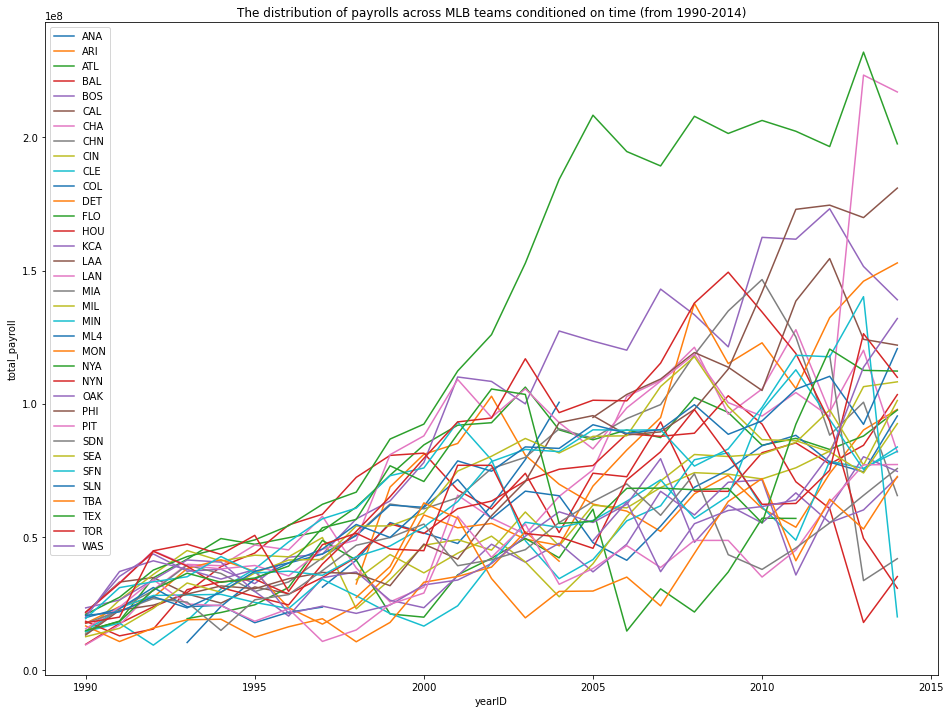

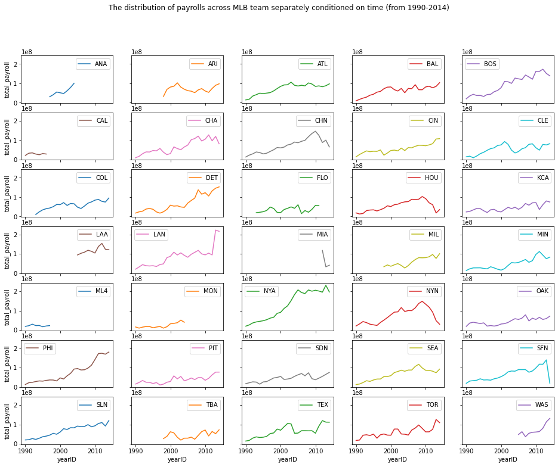

```python
# Create a copy of the original salaries_winnings dataframe
payrolls_time = salaries_winnings

# Extract the data from the dataframe copy from year 1990-2014
payrolls_time = payrolls_time[payrolls_time["yearID"].apply(lambda x: x >= 1990 and x <= 2014)]

# Drop the unneeded columns from the dataframe (only want teamID, yearID, and total_payroll)
payrolls_time = payrolls_time.drop(columns=["franchiseID", "wins", "games", "winning_percentage"])

# Set the DataFrame index (row labels) to yearID for the x-axis of the plot
payrolls_time.set_index("yearID", inplace=True)

# The line graph of the distribution of payrolls of all teams on the same plot
payrolls_time.groupby(["teamID"])["total_payroll"].plot(x="yearID", ylabel="total_payroll", figsize=(16,12),
                                                        title="The distribution of payrolls across MLB teams conditioned on time (from 1990-2014)", legend=True)

# The line graph of the distribution of payrolls of each team seprately on subplots
pd.pivot_table(payrolls_time.reset_index(), index="yearID", columns="teamID", values="total_payroll"
              ).plot(xlabel="yearID", ylabel="total_payroll", title="The distribution of payrolls across MLB team separately conditioned on time (from 1990-2014)",
                     figsize=(16,12), subplots=True, layout=(7,5), sharex=True, sharey=True)
```

# Write-up for Part 2 Problem 2:

```
In this part, the goal is to plot the distribution of payrolls of the teams conditioned on time (from 1990 to 2014). In order to achieve that, we first need to extract the data we need for our graph, so I created a dataframe copy of the original one and dropped the unneeded columns and perserved only the rows within the year range. Then, I called groupby("teamID") on the dataframe to group the data by each team and make the visualization.

The first graph is a line graph with all of the distributions of payrolls of teams over the years on the same plot. The second graph is subplots of a line graph of the distribution of payrolls for each team separately over the years.
```

# Question 1: What statements can you make about the distribution of payrolls conditioned on time based on these plots?

```
If we take a look at each sub line graph, we can notice there are some missing data for some teams as their line graph is broken or shorter than the others. Therefore, we cannot conclude too much about the overall trending of the total payroll of teams. If we look at the line graph with all of the distributions of payrolls of teams together, we can observe that the average total payrolls have been increasing over the years from 1990 to 2014. Also, the spread of the data and variance have increased over the years from 1990 to 2014 as well since we can see that the differences of total_payrolls have become larger and larger among the teams.
```

# Problem 3: Write code to produce plots which show a statistic for central tendency vs. time based on observations from Question 1.

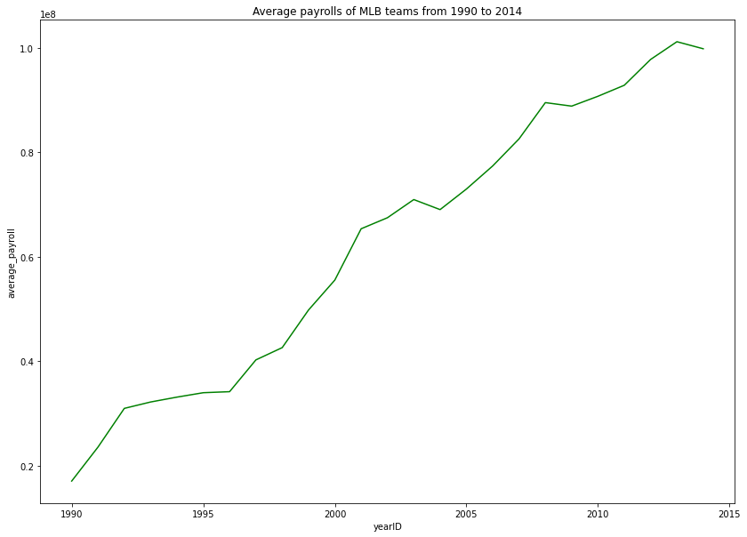

```python
# The line graph of mean payroll of all MLB teams combined from 1990 to 2014
payrolls_time.groupby("yearID")["total_payroll"].mean().plot(xlabel="yearID", ylabel="average_payroll", figsize=(14,10), c="green",
                                                             title="Average payrolls of MLB teams from 1990 to 2014")
```

# Write-up for Part 2 Problem 3:

```
This is a line graph of the central tendency of the distributions of mean payrolls of the MLB teams from 1990 to 2014 and it proves our previous observation that the average payrolls of teams have been increasing over the years.
```

# #2. Correlation between payroll and winning percentage

# Problem 4: Write code to discretize year into five time periods and make a scatterplot showing mean winning percentage vs. mean payroll for each of the five time periods.

```python
# Python packages used for building the desired scatter plots
import matplotlib.pyplot as plt
import numpy as np
from IPython import display

# Create a copy of the original salaries_winnings dataframe
payroll_winning = salaries_winnings

# Extract the data from the dataframe copy from year 1990-2014
payroll_winning = payroll_winning[payroll_winning["yearID"].apply(lambda x: x >= 1990 and x <= 2014)]

# Drop the unneeded columns from the dataframe (Only want teamID, yearID, total_payroll, and winning_percentage)
payroll_winning = payroll_winning.drop(columns=["franchiseID", "wins", "games"])

# Store a new column of the binning intervals for five time periods from year 1990-2014
payroll_winning["year_bins"] = pd.cut(x=payroll_winning["yearID"], bins=[1989, 1994, 1999, 2004, 2009, 2014])

# Calculate the average_payroll and average_winning_percentage for each team in each time period
payroll_winning = payroll_winning.groupby(["year_bins", "teamID"])[["total_payroll", "winning_percentage"]].mean()

# Rename the column names of the dataframe for average_payroll and average_winning_percentage
payroll_winning = payroll_winning.rename(columns={"total_payroll": "average_payroll", "winning_percentage": "average_winning_percentage"})

# Reset index for the dataframe
payroll_winning = payroll_winning.reset_index()

# Drop the rows with missing entries
payroll_winning = payroll_winning.dropna()

# Count how many teams have data entries for each time period
team_count = payroll_winning.groupby("year_bins").count()

# Visualization
display.display(payroll_winning)
display.display(team_count)
```

|  | year_bins | teamID | average_payroll | average_winning_percentage |
| --- | --- | --- | --- | --- |
| 2 | (1989, 1994] | ATL | 3.172185e+07 | 56.497726 |
| 3 | (1989, 1994] | BAL | 2.378520e+07 | 50.444080 |
| 4 | (1989, 1994] | BOS | 3.486322e+07 | 49.514761 |
| 5 | (1989, 1994] | CAL | 2.865478e+07 | 45.704777 |
| 6 | (1989, 1994] | CHA | 2.709040e+07 | 56.426308 |
| 7 | (1989, 1994] | CHN | 2.846067e+07 | 47.740117 |
| 8 | (1989, 1994] | CIN | 3.248967e+07 | 51.972088 |
| 9 | (1989, 1994] | CLE | 1.810931e+07 | 46.990058 |
| 10 | (1989, 1994] | COL | 1.712042e+07 | 43.328585 |
| 11 | (1989, 1994] | DET | 2.967021e+07 | 49.093935 |
| 12 | (1989, 1994] | FLO | 2.048177e+07 | 41.926999 |
| 13 | (1989, 1994] | HOU | 2.198530e+07 | 49.256039 |
| 14 | (1989, 1994] | KCA | 3.309245e+07 | 49.829921 |
| 16 | (1989, 1994] | LAN | 3.524591e+07 | 50.051982 |
| 19 | (1989, 1994] | MIN | 2.452962e+07 | 50.121272 |
| 20 | (1989, 1994] | ML4 | 2.440113e+07 | 48.476651 |
| 21 | (1989, 1994] | MON | 1.622768e+07 | 54.570642 |
| 22 | (1989, 1994] | NYA | 3.483121e+07 | 49.673331 |
| 23 | (1989, 1994] | NYN | 3.378302e+07 | 46.707138 |
| 24 | (1989, 1994] | OAK | 3.398130e+07 | 52.280702 |
| 25 | (1989, 1994] | PHI | 2.403643e+07 | 49.144391 |
| 26 | (1989, 1994] | PIT | 2.443491e+07 | 54.236517 |
| 27 | (1989, 1994] | SDN | 2.140403e+07 | 45.318139 |
| 28 | (1989, 1994] | SEA | 2.267003e+07 | 46.527778 |
| 29 | (1989, 1994] | SFN | 3.223097e+07 | 50.923242 |
| 30 | (1989, 1994] | SLN | 2.452202e+07 | 49.217391 |
| 32 | (1989, 1994] | TEX | 2.651552e+07 | 49.987005 |
| 33 | (1989, 1994] | TOR | 3.463215e+07 | 54.997316 |
| 35 | (1994, 1999] | ANA | 4.260155e+07 | 49.176955 |
| 36 | (1994, 1999] | ARI | 5.052550e+07 | 50.925926 |

[output cut: 121 more lines]

| year_bins | teamID | average_payroll | average_winning_percentage |
| --- | --- | --- | --- |
| (1989, 1994] | 28 | 28 | 28 |
| (1994, 1999] | 32 | 32 | 32 |
| (1999, 2004] | 30 | 30 | 30 |
| (2004, 2009] | 30 | 30 | 30 |
| (2009, 2014] | 31 | 31 | 31 |

# 1) Scatter plot of mean winning percentage vs. mean payroll from 1990-1994

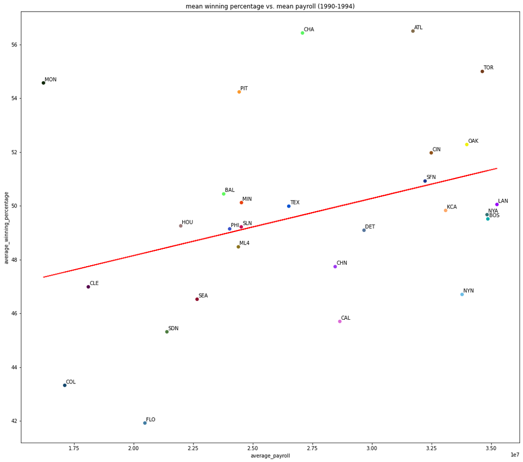

```python
# Use the number of counts for each time period to extract data from 1990-1994
payroll_winning_1 = payroll_winning.iloc[0:28]

# Re-index the extracted dataframe
payroll_winning_1.index = np.arange(0, len(payroll_winning_1))

# Store the data columns needed for the scatter plot into variables for convention
average_payroll_1 = payroll_winning_1["average_payroll"]
average_winning_percentage_1 = payroll_winning_1["average_winning_percentage"]
teamID_1 = payroll_winning_1["teamID"]

# Set the display size of the scatter plot
plt.figure(figsize=(18,16))

# Scatter plot with mean winning percentage (y-axis) vs. mean payroll (x-axis) from year 1990-1994
plt.scatter(average_payroll_1, average_winning_percentage_1, c=np.random.rand(len(average_payroll_1),3))

# Add appropriate labels and title to the plot
plt.title("mean winning percentage vs. mean payroll (1990-1994)")
plt.xlabel("average_payroll")
plt.ylabel("average_winning_percentage")

# Label the points in the scatter plot with teamID
for i, team in enumerate (teamID_1):
    plt.text(average_payroll_1[i]+50000, average_winning_percentage_1[i]+0.07, team)

# Obtain m (slope) and b (intercept) of linear regression line
m, b = np.polyfit(average_payroll_1, average_winning_percentage_1, 1)

# Use red as color for plotting the regression line
plt.plot(average_payroll_1, m*average_payroll_1+b, c="red")
```

# 2) Scatter plot of mean winning percentage vs. mean payroll from 1995-1999

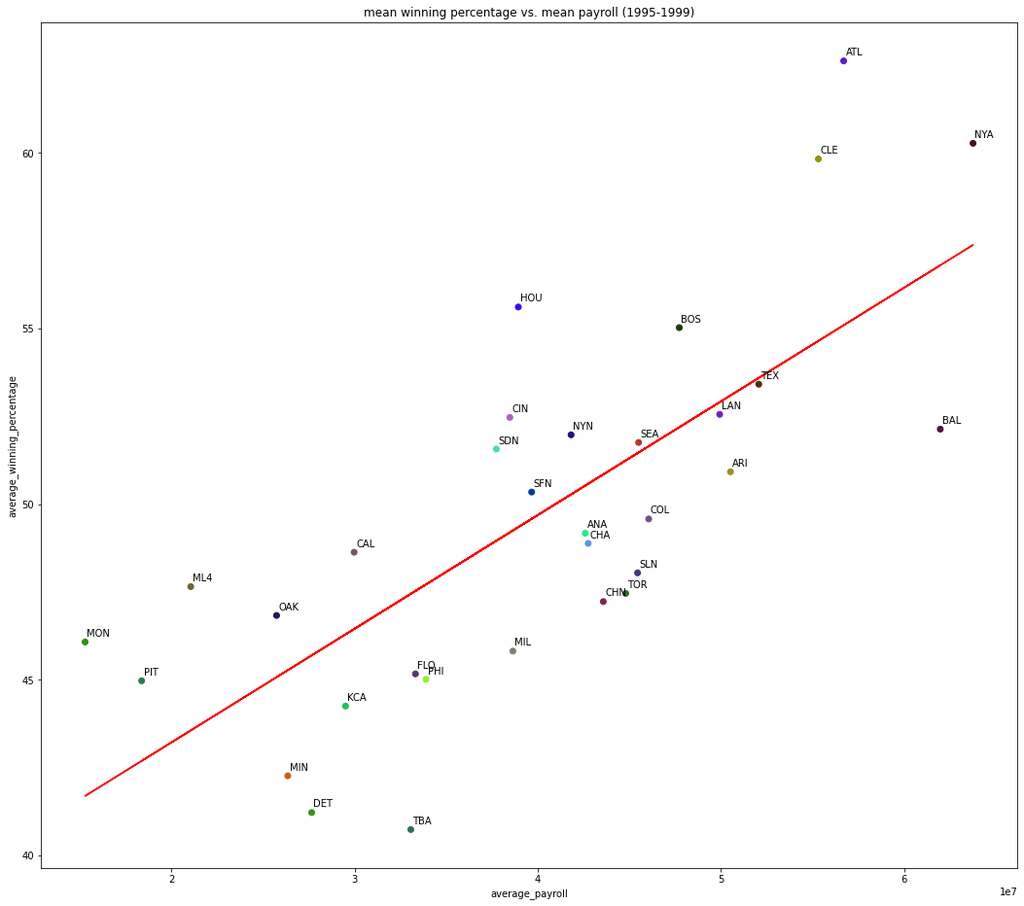

```python
# Use the number of counts for each time period to extract data from 1995-1999
payroll_winning_2 = payroll_winning.iloc[28:60]

# Re-index the extracted dataframe
payroll_winning_2.index = np.arange(0, len(payroll_winning_2))

# Store the data columns needed for the scatter plot into variables for convention
average_payroll_2 = payroll_winning_2["average_payroll"]
average_winning_percentage_2 = payroll_winning_2["average_winning_percentage"]
teamID_2 = payroll_winning_2["teamID"]

# Set the display size of the scatter plot
plt.figure(figsize=(18,16))

# Scatter plot with mean winning percentage (y-axis) vs. mean payroll (x-axis) from year 1995-1999
plt.scatter(average_payroll_2, average_winning_percentage_2, c=np.random.rand(len(average_payroll_2),3))

# Add appropriate labels and title to the plot
plt.title("mean winning percentage vs. mean payroll (1995-1999)")
plt.xlabel("average_payroll")
plt.ylabel("average_winning_percentage")

# Label the points in the scatter plot with teamID
for i, team in enumerate (teamID_2):
    plt.text(average_payroll_2[i]+100000, average_winning_percentage_2[i]+0.15, team)

# Obtain m (slope) and b (intercept) of linear regression line
m, b = np.polyfit(average_payroll_2, average_winning_percentage_2, 1)

# Use red as color for plotting the regression line
plt.plot(average_payroll_2, m*average_payroll_2+b, c="red")
```

# 3) Scatter plot of mean winning percentage vs. mean payroll from 2000-2004

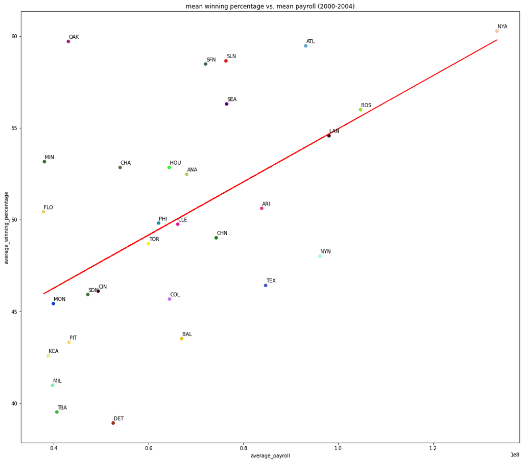

```python
# Use the number of counts for each time period to extract data from 2000-2004
payroll_winning_3 = payroll_winning.iloc[60:90]

# Re-index the extracted dataframe
payroll_winning_3.index = np.arange(0, len(payroll_winning_3))

# Store the data columns needed for the scatter plot into variables for convention
average_payroll_3 = payroll_winning_3["average_payroll"]
average_winning_percentage_3 = payroll_winning_3["average_winning_percentage"]
teamID_3 = payroll_winning_3["teamID"]

# Set the display size of the scatter plot
plt.figure(figsize=(18,16))

# Scatter plot with mean winning percentage (y-axis) vs. mean payroll (x-axis) from year 2000-2004
plt.scatter(average_payroll_3, average_winning_percentage_3, c=np.random.rand(len(average_payroll_3),3))

# Add appropriate labels and title to the plot
plt.title("mean winning percentage vs. mean payroll (2000-2004)")
plt.xlabel("average_payroll")
plt.ylabel("average_winning_percentage")

# Label the points in the scatter plot with teamID
for i, team in enumerate (teamID_3):
    plt.text(average_payroll_3[i]+100000, average_winning_percentage_3[i]+0.15, team)

# Obtain m (slope) and b (intercept) of linear regression line
m, b = np.polyfit(average_payroll_3, average_winning_percentage_3, 1)

# Use red as color for plotting the regression line
plt.plot(average_payroll_3, m*average_payroll_3+b, c="red")
```

# 4) Scatter plot of mean winning percentage vs. mean payroll from 2005-2009

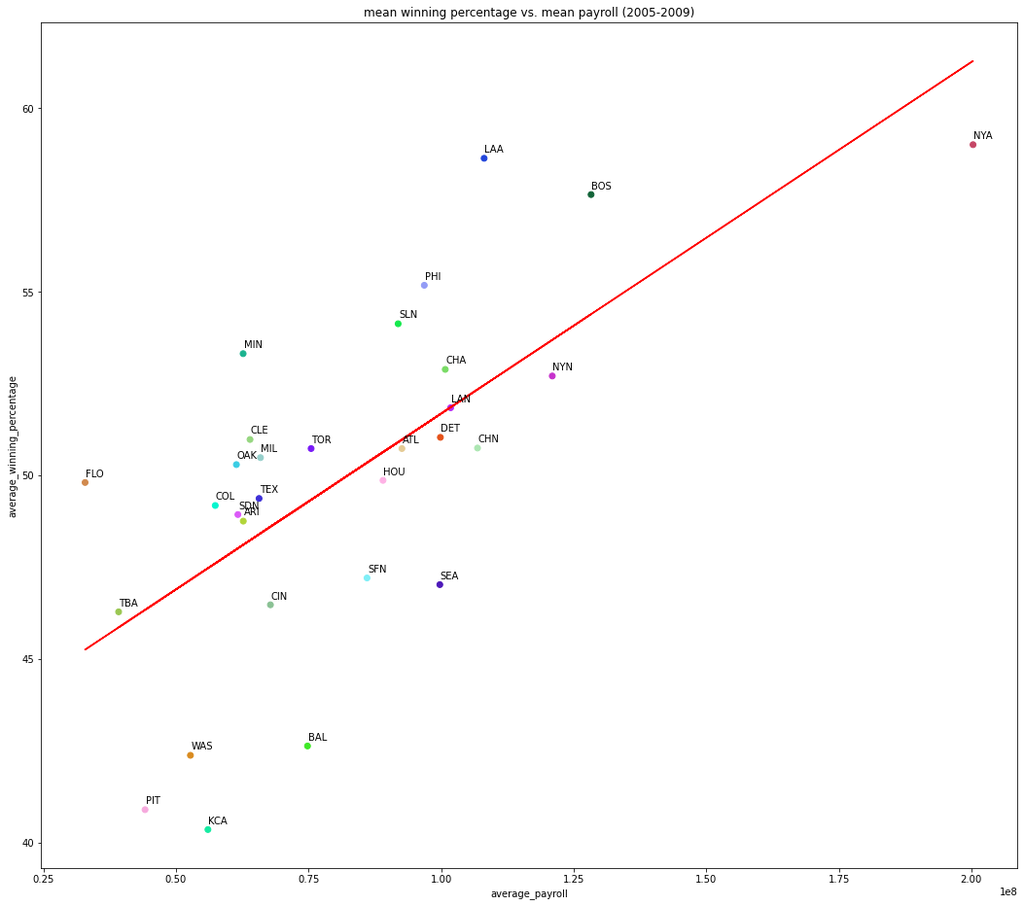

```python
# Use the number of counts for each time period to extract data from 2005-2009
payroll_winning_4 = payroll_winning.iloc[90:120]

# Re-index the extracted dataframe
payroll_winning_4.index = np.arange(0, len(payroll_winning_4))

# Store the data columns needed for the scatter plot into variables for convention
average_payroll_4 = payroll_winning_4["average_payroll"]
average_winning_percentage_4 = payroll_winning_4["average_winning_percentage"]
teamID_4 = payroll_winning_4["teamID"]

# Set the display size of the scatter plot
plt.figure(figsize=(18,16))

# Scatter plot with mean winning percentage (y-axis) vs. mean payroll (x-axis) from year 2005-2009
plt.scatter(average_payroll_4, average_winning_percentage_4, c=np.random.rand(len(average_payroll_4),3))

# Add appropriate labels and title to the plot
plt.title("mean winning percentage vs. mean payroll (2005-2009)")
plt.xlabel("average_payroll")
plt.ylabel("average_winning_percentage")

# Label the points in the scatter plot with teamID
for i, team in enumerate (teamID_4):
    plt.text(average_payroll_4[i]+100000, average_winning_percentage_4[i]+0.15, team)

# Obtain m (slope) and b (intercept) of linear regression line
m, b = np.polyfit(average_payroll_4, average_winning_percentage_4, 1)

# Use red as color for plotting the regression line
plt.plot(average_payroll_4, m*average_payroll_4+b, c="red")
```

# 5) Scatter plot of mean winning percentage vs. mean payroll from 2010-2014

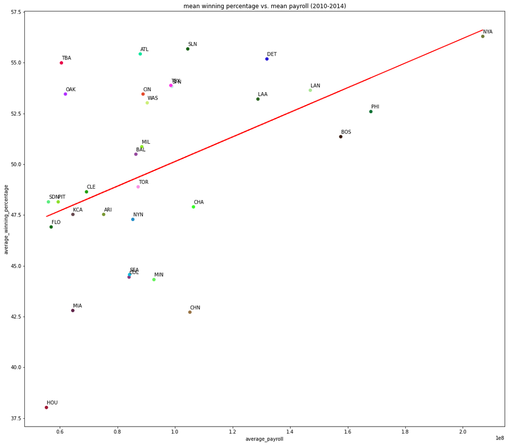

```python
# Use the number of counts for each time period to extract data from 2010-2014
payroll_winning_5 = payroll_winning.iloc[120:151]

# Re-index the extracted dataframe
payroll_winning_5.index = np.arange(0, len(payroll_winning_5))

# Store the data columns needed for the scatter plot into variables for convention
average_payroll_5 = payroll_winning_5["average_payroll"]
average_winning_percentage_5 = payroll_winning_5["average_winning_percentage"]
teamID_5 = payroll_winning_5["teamID"]

# Set the display size of the scatter plot
plt.figure(figsize=(18,16))

# Scatter plot with mean winning percentage (y-axis) vs. mean payroll (x-axis) from year 2010-2014
plt.scatter(average_payroll_5, average_winning_percentage_5, c=np.random.rand(len(average_payroll_5),3))

# Add appropriate labels and title to the plot
plt.title("mean winning percentage vs. mean payroll (2010-2014)")
plt.xlabel("average_payroll")
plt.ylabel("average_winning_percentage")

# Label the points in the scatter plot with teamID
for i, team in enumerate (teamID_5):
    plt.text(average_payroll_5[i]+100000, average_winning_percentage_5[i]+0.15, team)

# Obtain m (slope) and b (intercept) of linear regression line
m, b = np.polyfit(average_payroll_5, average_winning_percentage_5, 1)

# Use red as color for plotting the regression line
plt.plot(average_payroll_5, m*average_payroll_5+b, c="red")
```

# Write-up for Part 2 Problem 4:

```
In this part, the goal is to break down the data set from 1990-2014 into five even time periods and create a scatter plot for each time period comparing the mean winning percentage vs. the mean payroll for each team.

My approach was to first extract a copy of the dataframe and drop the unneeded columns. Then, I used pd.cut(x=payroll_winning["yearID"], bins=[1989, 1994, 1999, 2004, 2009, 2014]) to bin the dataframe into five time periods based on the yearID. This allows us to group the dataframe by the binning time intervals and calculate the average payroll and average winning percentage accordingly. Lastly, we drop the rows with missing entries in our table and count the number of instances for each time period.

Now, it is ready for plotting. We use the count of teams in each time period to break the dataframe into five separate dataframes based on the time period and generate a scatter plot separately for each one of them and label the points and draw the linear regression line.
```

# Question 2: What can you say about team payrolls across these periods? Are there any teams that standout as being particularly good at paying for wins across these time periods? What can you say about the Oakland A's spending efficiency across these time periods

[output not shown]

# Part 3: Data transformations

# #1. Standardizing across years

# Problem 5: Create a new variable in your dataset that standardizes payroll conditioned on year.

```python
# Drop the unneeded columns from the dataframe (only want teamID, yearID, and total_payroll)
std_payroll = salaries_winnings.drop(columns=["franchiseID", "wins", "games"])

# Calculate the sum of total_payroll for each year
sum_payroll = std_payroll.groupby("yearID")["total_payroll"].sum()

# Calculate the count of the total_payroll for each year
count_payroll = std_payroll.groupby("yearID")["total_payroll"].count()

# Calculate the standard deviation of total_payroll for each year
std_per_year = std_payroll.groupby("yearID")["total_payroll"].std()

# Merge (sum_payroll / count_payroll) as a column of average payroll for each year and the std_payroll dataframe by left join on yearID
std_payroll = pd.merge(std_payroll, (sum_payroll / count_payroll), on=["yearID"])

# Merge std_per_year as a column of standard deviation of payroll for each year and the std_payroll dataframe by left join on yearID
std_payroll = pd.merge(std_payroll, std_per_year, on=["yearID"])

# Rename the columns to appropriate labels
std_payroll = std_payroll.rename(columns={"total_payroll_x": "total_payroll", "total_payroll_y": "average_payroll", "total_payroll": "std_by_year"})

# Use the formula for standardized payroll for team i in year j to calculate the values and store them in a new column on the dataframe
std_payroll["standardized_payroll"] = (std_payroll["total_payroll"] - std_payroll["average_payroll"]) / std_payroll["std_by_year"]

# Extract the data from the dataframe copy from year 1990-2014
std_payroll = std_payroll[std_payroll["yearID"].apply(lambda x: x >= 1990 and x <= 2014)]

# Visualization
std_payroll
```

|  | teamID | yearID | total_payroll | winning_percentage | average_payroll | std_by_year | standardized_payroll |
| --- | --- | --- | --- | --- | --- | --- | --- |
| 130 | ATL | 1990 | 14555501.0 | 40.123457 | 1.707235e+07 | 3.771834e+06 | -0.667275 |
| 131 | BAL | 1990 | 9680084.0 | 47.204969 | 1.707235e+07 | 3.771834e+06 | -1.959861 |
| 132 | BOS | 1990 | 20558333.0 | 54.320988 | 1.707235e+07 | 3.771834e+06 | 0.924213 |
| 133 | CAL | 1990 | 21720000.0 | 49.382716 | 1.707235e+07 | 3.771834e+06 | 1.232198 |
| 134 | CHA | 1990 | 9491500.0 | 58.024691 | 1.707235e+07 | 3.771834e+06 | -2.009859 |
| 135 | CHN | 1990 | 13624000.0 | 47.530864 | 1.707235e+07 | 3.771834e+06 | -0.914238 |
| 136 | CIN | 1990 | 14370000.0 | 56.172840 | 1.707235e+07 | 3.771834e+06 | -0.716456 |
| 137 | CLE | 1990 | 14487000.0 | 47.530864 | 1.707235e+07 | 3.771834e+06 | -0.685437 |
| 138 | DET | 1990 | 17593238.0 | 48.765432 | 1.707235e+07 | 3.771834e+06 | 0.138098 |
| 139 | HOU | 1990 | 18330000.0 | 46.296296 | 1.707235e+07 | 3.771834e+06 | 0.333431 |
| 140 | KCA | 1990 | 23361084.0 | 46.583851 | 1.707235e+07 | 3.771834e+06 | 1.667287 |
| 141 | LAN | 1990 | 21318704.0 | 53.086420 | 1.707235e+07 | 3.771834e+06 | 1.125805 |
| 142 | MIN | 1990 | 14602000.0 | 45.679012 | 1.707235e+07 | 3.771834e+06 | -0.654948 |
| 143 | ML4 | 1990 | 19719167.0 | 45.679012 | 1.707235e+07 | 3.771834e+06 | 0.701731 |
| 144 | MON | 1990 | 16586388.0 | 52.469136 | 1.707235e+07 | 3.771834e+06 | -0.128841 |
| 145 | NYA | 1990 | 20912318.0 | 41.358025 | 1.707235e+07 | 3.771834e+06 | 1.018063 |
| 146 | NYN | 1990 | 21722834.0 | 56.172840 | 1.707235e+07 | 3.771834e+06 | 1.232949 |
| 147 | OAK | 1990 | 19887501.0 | 63.580247 | 1.707235e+07 | 3.771834e+06 | 0.746360 |
| 148 | PHI | 1990 | 13173667.0 | 47.530864 | 1.707235e+07 | 3.771834e+06 | -1.033631 |
| 149 | PIT | 1990 | 15556000.0 | 58.641975 | 1.707235e+07 | 3.771834e+06 | -0.402020 |
| 150 | SDN | 1990 | 17588334.0 | 46.296296 | 1.707235e+07 | 3.771834e+06 | 0.136798 |
| 151 | SEA | 1990 | 12553667.0 | 47.530864 | 1.707235e+07 | 3.771834e+06 | -1.198008 |
| 152 | SFN | 1990 | 19335333.0 | 52.469136 | 1.707235e+07 | 3.771834e+06 | 0.599968 |
| 153 | SLN | 1990 | 20523334.0 | 43.209877 | 1.707235e+07 | 3.771834e+06 | 0.914934 |
| 154 | TEX | 1990 | 14874372.0 | 51.234568 | 1.707235e+07 | 3.771834e+06 | -0.582735 |
| 155 | TOR | 1990 | 17756834.0 | 53.086420 | 1.707235e+07 | 3.771834e+06 | 0.181472 |
| 156 | ATL | 1991 | 18403500.0 | 58.024691 | 2.357879e+07 | 6.894669e+06 | -0.750621 |
| 157 | BAL | 1991 | 17519000.0 | 41.358025 | 2.357879e+07 | 6.894669e+06 | -0.878909 |
| 158 | BOS | 1991 | 35167500.0 | 51.851852 | 2.357879e+07 | 6.894669e+06 | 1.680823 |
| 159 | CAL | 1991 | 33060001.0 | 50.000000 | 2.357879e+07 | 6.894669e+06 | 1.375152 |

[output cut: 698 more lines]

# Write-up for Part 3 Problem 5:

```
In this part, the goal is to create a new column in our dataframe for the calculations of the standardized payroll of each team in each year from 1990-2014. In order to achieve this, I first created columns for calculations of the average payroll of each year and standard deviation of payroll of each year and left join them on the original dataframe copy. Then, I was able to calculate the standardized payroll by the formula (total_payroll - average payroll by year) / (standard deviation by year).
```

# Problem 6: Repeat the same plots as Problem 4, but use this new standardized payroll variable.

```python
# Python packages used for building the desired scatter plots
import matplotlib.pyplot as plt
import numpy as np
from IPython import display

# Create a copy of the original std_payroll dataframe for plotting
std_payroll_scatter = std_payroll

# Store a new column of the binning intervals for five time periods from year 1990-2014
std_payroll_scatter["year_bins"] = pd.cut(x=std_payroll_scatter["yearID"], bins=[1989, 1994, 1999, 2004, 2009, 2014])

# Calculate the average_winning_percentage and average_standardized_payroll for each team in each time period and store the values in a new dataframe
average_std_payroll = std_payroll_scatter.groupby(["year_bins", "teamID"])[["winning_percentage", "standardized_payroll"]].mean()

# Reset index for the average_std_payroll table
average_std_payroll = average_std_payroll.reset_index()

# Rename the column names of the dataframe for average_winning_percentage and average_standardized_payroll
average_std_payroll = average_std_payroll.rename(columns={"winning_percentage": "average_winning_percentage", "standardized_payroll": "average_standardized_payroll"})

# Drop the rows with missing entries
average_std_payroll = average_std_payroll.dropna()

# Count how many teams have data entries for each time period
team_count = average_std_payroll.groupby("year_bins").count()

# Visualization
display.display(average_std_payroll)
display.display(team_count)
```

|  | year_bins | teamID | average_winning_percentage | average_standardized_payroll |
| --- | --- | --- | --- | --- |
| 2 | (1989, 1994] | ATL | 56.497726 | 0.381441 |
| 3 | (1989, 1994] | BAL | 50.444080 | -0.658533 |
| 4 | (1989, 1994] | BOS | 49.514761 | 1.014231 |
| 5 | (1989, 1994] | CAL | 45.704777 | 0.338304 |
| 6 | (1989, 1994] | CHA | 56.426308 | -0.309019 |
| 7 | (1989, 1994] | CHN | 47.740117 | 0.009713 |
| 8 | (1989, 1994] | CIN | 51.972088 | 0.502029 |
| 9 | (1989, 1994] | CLE | 46.990058 | -1.139435 |
| 10 | (1989, 1994] | COL | 43.328585 | -1.725668 |
| 11 | (1989, 1994] | DET | 49.093935 | 0.278809 |
| 12 | (1989, 1994] | FLO | 41.926999 | -1.371662 |
| 13 | (1989, 1994] | HOU | 49.256039 | -0.628339 |
| 14 | (1989, 1994] | KCA | 49.829921 | 0.848256 |
| 16 | (1989, 1994] | LAN | 50.051982 | 1.062550 |
| 19 | (1989, 1994] | MIN | 50.121272 | -0.398411 |
| 20 | (1989, 1994] | ML4 | 48.476651 | -0.260381 |
| 21 | (1989, 1994] | MON | 54.570642 | -1.347215 |
| 22 | (1989, 1994] | NYA | 49.673331 | 0.977297 |
| 23 | (1989, 1994] | NYN | 46.707138 | 0.902674 |
| 24 | (1989, 1994] | OAK | 52.280702 | 0.904035 |
| 25 | (1989, 1994] | PHI | 49.144391 | -0.498106 |
| 26 | (1989, 1994] | PIT | 54.236517 | -0.383145 |
| 27 | (1989, 1994] | SDN | 45.318139 | -0.676595 |
| 28 | (1989, 1994] | SEA | 46.527778 | -0.719934 |
| 29 | (1989, 1994] | SFN | 50.923242 | 0.666438 |
| 30 | (1989, 1994] | SLN | 49.217391 | -0.223151 |
| 32 | (1989, 1994] | TEX | 49.987005 | -0.203992 |
| 33 | (1989, 1994] | TOR | 54.997316 | 0.799410 |
| 35 | (1994, 1999] | ANA | 49.176955 | -0.171200 |
| 36 | (1994, 1999] | ARI | 50.925926 | 0.125901 |

[output cut: 121 more lines]

| year_bins | teamID | average_winning_percentage | average_standardized_payroll |
| --- | --- | --- | --- |
| (1989, 1994] | 28 | 28 | 28 |
| (1994, 1999] | 32 | 32 | 32 |
| (1999, 2004] | 30 | 30 | 30 |
| (2004, 2009] | 30 | 30 | 30 |
| (2009, 2014] | 31 | 31 | 31 |

# 1) Scatter plot of mean winning percentage vs. mean standardized payroll from 1990-1994

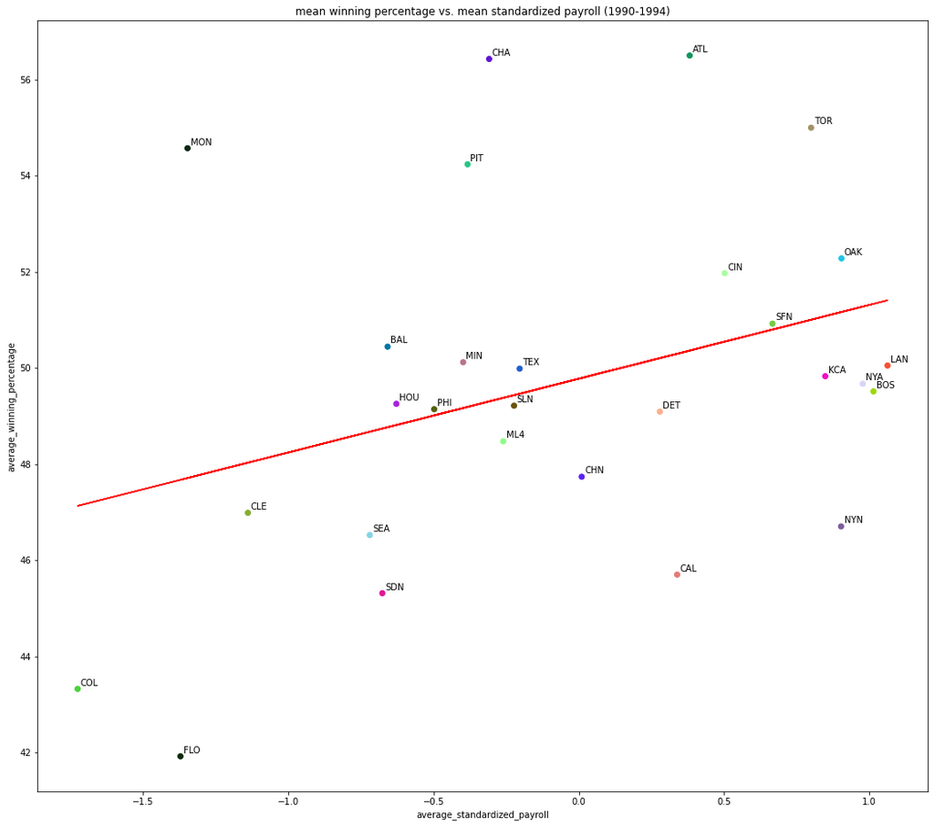

```python
# Use the number of counts for each time period to extract data from 1990-1994
average_std_payroll_1 = average_std_payroll.iloc[0:28]

# Re-index the extracted dataframe
average_std_payroll_1.index = np.arange(0, len(average_std_payroll_1))

# Store the data columns needed for the scatter plot into variables for convention
average_standardized_payroll_1 = average_std_payroll_1["average_standardized_payroll"]
average_winning_percentage_1 = average_std_payroll_1["average_winning_percentage"]
teamID_1 = average_std_payroll_1["teamID"]

# Set the display size of the scatter plot
plt.figure(figsize=(18,16))

# Scatter plot with mean winning percentage (y-axis) vs. mean standardized payroll (x-axis) from year 1990-1994
plt.scatter(average_standardized_payroll_1, average_winning_percentage_1, c=np.random.rand(len(average_standardized_payroll_1),3))

# Add appropriate labels and title to the plot
plt.title("mean winning percentage vs. mean standardized payroll (1990-1994)")
plt.xlabel("average_standardized_payroll")
plt.ylabel("average_winning_percentage")

# Label the points in the scatter plot with teamID
for i, team in enumerate (teamID_1):
    plt.text(average_standardized_payroll_1[i]+0.01, average_winning_percentage_1[i]+0.07, team)

# Obtain m (slope) and b (intercept) of linear regression line
m, b = np.polyfit(average_standardized_payroll_1, average_winning_percentage_1, 1)

# Use red as color for plotting the regression line
plt.plot(average_standardized_payroll_1, m*average_standardized_payroll_1+b, c="red")
```

# 2) Scatter plot of mean winning percentage vs. mean standardized payroll from 1995-1999

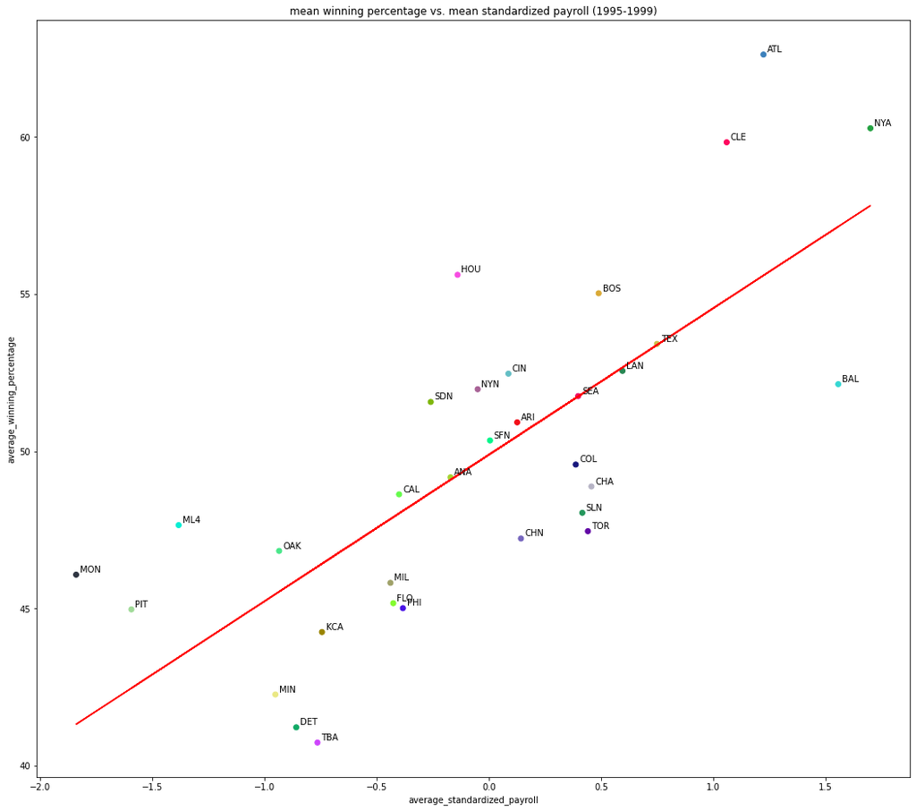

```python
# Use the number of counts for each time period to extract data from 1995-1999
average_std_payroll_2 = average_std_payroll.iloc[28:60]

# Re-index the extracted dataframe
average_std_payroll_2.index = np.arange(0, len(average_std_payroll_2))

# Store the data columns needed for the scatter plot into variables for convention
average_standardized_payroll_2 = average_std_payroll_2["average_standardized_payroll"]
average_winning_percentage_2 = average_std_payroll_2["average_winning_percentage"]
teamID_2 = average_std_payroll_2["teamID"]

# Set the display size of the scatter plot
plt.figure(figsize=(18,16))

# Scatter plot with mean winning percentage (y-axis) vs. mean standardized payroll (x-axis) from year 1995-1999
plt.scatter(average_standardized_payroll_2, average_winning_percentage_2, c=np.random.rand(len(average_standardized_payroll_2),3))

# Add appropriate labels and title to the plot
plt.title("mean winning percentage vs. mean standardized payroll (1995-1999)")
plt.xlabel("average_standardized_payroll")
plt.ylabel("average_winning_percentage")

# Label the points in the scatter plot with teamID
for i, team in enumerate (teamID_2):
    plt.text(average_standardized_payroll_2[i]+0.017, average_winning_percentage_2[i]+0.07, team)

# Obtain m (slope) and b (intercept) of linear regression line
m, b = np.polyfit(average_standardized_payroll_2, average_winning_percentage_2, 1)

# Use red as color for plotting the regression line
plt.plot(average_standardized_payroll_2, m*average_standardized_payroll_2+b, c="red")
```

# 3) Scatter plot of mean winning percentage vs. mean standardized payroll from 2000-2004

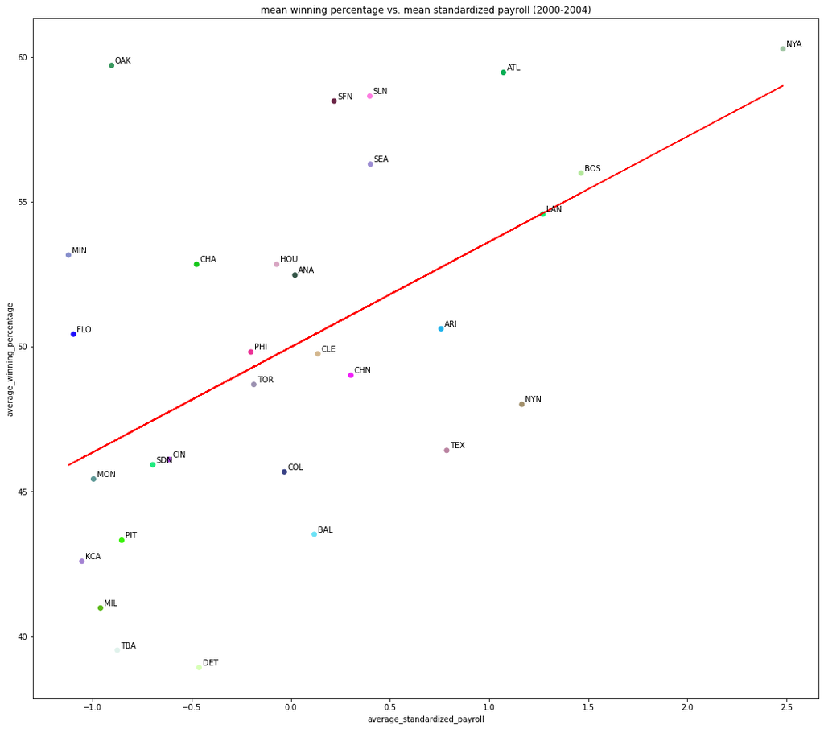

```python
# Use the number of counts for each time period to extract data from 2000-2004
average_std_payroll_3 = average_std_payroll.iloc[60:90]

# Re-index the extracted dataframe
average_std_payroll_3.index = np.arange(0, len(average_std_payroll_3))

# Store the data columns needed for the scatter plot into variables for convention
average_standardized_payroll_3 = average_std_payroll_3["average_standardized_payroll"]
average_winning_percentage_3 = average_std_payroll_3["average_winning_percentage"]
teamID_3 = average_std_payroll_3["teamID"]

# Set the display size of the scatter plot
plt.figure(figsize=(18,16))

# Scatter plot with mean winning percentage (y-axis) vs. mean standardized payroll (x-axis) from year 2000-2004
plt.scatter(average_standardized_payroll_3, average_winning_percentage_3, c=np.random.rand(len(average_standardized_payroll_3),3))

# Add appropriate labels and title to the plot
plt.title("mean winning percentage vs. mean standardized payroll (2000-2004)")
plt.xlabel("average_standardized_payroll")
plt.ylabel("average_winning_percentage")

# Label the points in the scatter plot with teamID
for i, team in enumerate (teamID_3):
    plt.text(average_standardized_payroll_3[i]+0.017, average_winning_percentage_3[i]+0.07, team)

# Obtain m (slope) and b (intercept) of linear regression line
m, b = np.polyfit(average_standardized_payroll_3, average_winning_percentage_3, 1)

# Use red as color for plotting the regression line
plt.plot(average_standardized_payroll_3, m*average_standardized_payroll_3+b, c="red")
```

# 4) Scatter plot of mean winning percentage vs. mean standardized payroll from 2005-2009

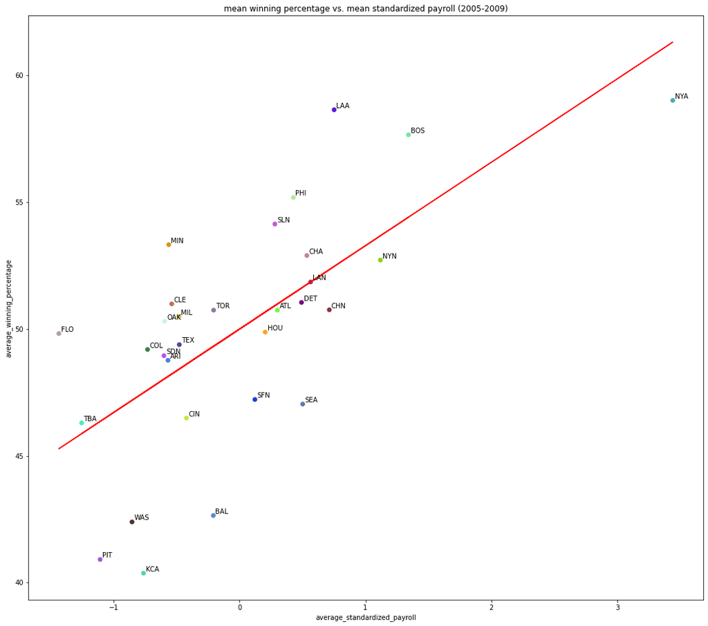

```python
# Use the number of counts for each time period to extract data from 2005-2009
average_std_payroll_4 = average_std_payroll.iloc[90:120]

# Re-index the extracted dataframe
average_std_payroll_4.index = np.arange(0, len(average_std_payroll_4))

# Store the data columns needed for the scatter plot into variables for convention
average_standardized_payroll_4 = average_std_payroll_4["average_standardized_payroll"]
average_winning_percentage_4 = average_std_payroll_4["average_winning_percentage"]
teamID_4 = average_std_payroll_4["teamID"]

# Set the display size of the scatter plot
plt.figure(figsize=(18,16))

# Scatter plot with mean winning percentage (y-axis) vs. mean standardized payroll (x-axis) from year 2005-2009
plt.scatter(average_standardized_payroll_4, average_winning_percentage_4, c=np.random.rand(len(average_standardized_payroll_4),3))

# Add appropriate labels and title to the plot
plt.title("mean winning percentage vs. mean standardized payroll (2005-2009)")
plt.xlabel("average_standardized_payroll")
plt.ylabel("average_winning_percentage")

# Label the points in the scatter plot with teamID
for i, team in enumerate (teamID_4):
    plt.text(average_standardized_payroll_4[i]+0.017, average_winning_percentage_4[i]+0.07, team)

# Obtain m (slope) and b (intercept) of linear regression line
m, b = np.polyfit(average_standardized_payroll_4, average_winning_percentage_4, 1)

# Use red as color for plotting the regression line
plt.plot(average_standardized_payroll_4, m*average_standardized_payroll_4+b, c="red")
```

# 5) Scatter plot of mean winning percentage vs. mean standardized payroll from 2010-2014

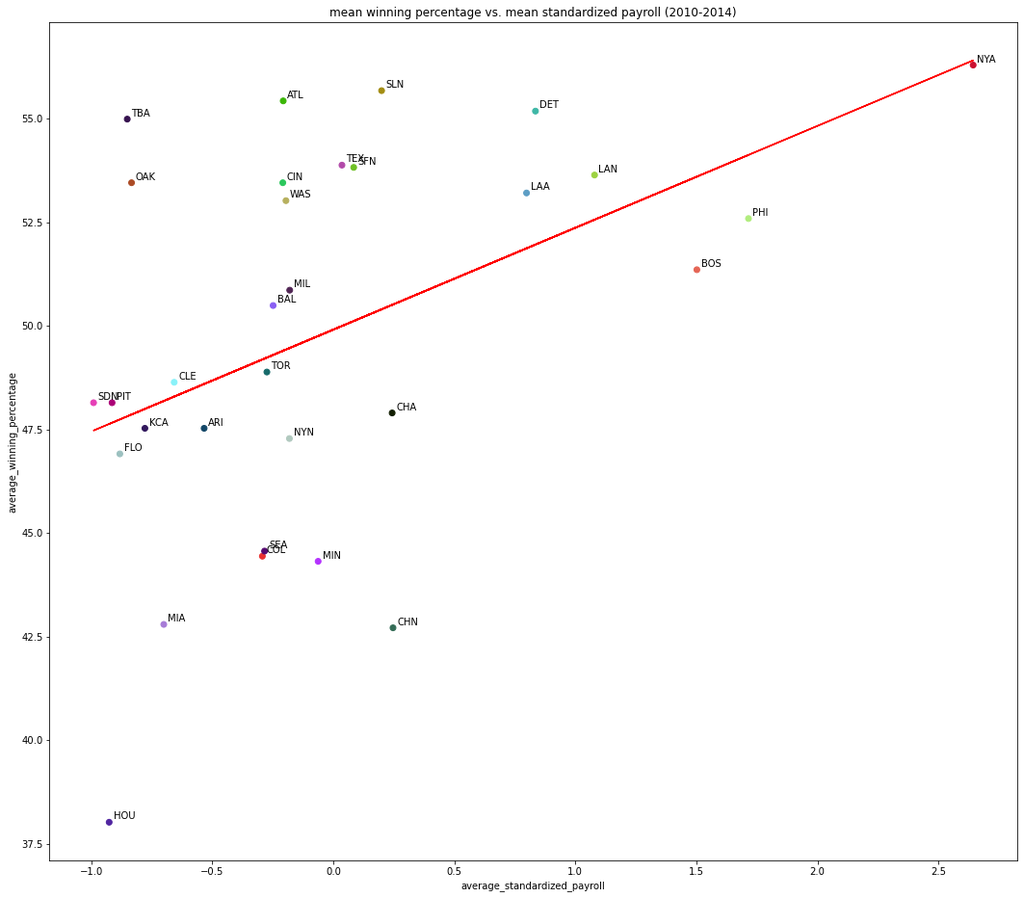

```python
# Use the number of counts for each time period to extract data from 2010-2014
average_std_payroll_5 = average_std_payroll.iloc[120:151]

# Re-index the extracted dataframe
average_std_payroll_5.index = np.arange(0, len(average_std_payroll_5))

# Store the data columns needed for the scatter plot into variables for convention
average_standardized_payroll_5 = average_std_payroll_5["average_standardized_payroll"]
average_winning_percentage_5 = average_std_payroll_5["average_winning_percentage"]
teamID_5 = average_std_payroll_5["teamID"]

# Set the display size of the scatter plot
plt.figure(figsize=(18,16))

# Scatter plot with mean winning percentage (y-axis) vs. mean standardized payroll (x-axis) from year 2010-2014
plt.scatter(average_standardized_payroll_5, average_winning_percentage_5, c=np.random.rand(len(average_standardized_payroll_5),3))

# Add appropriate labels and title to the plot
plt.title("mean winning percentage vs. mean standardized payroll (2010-2014)")
plt.xlabel("average_standardized_payroll")
plt.ylabel("average_winning_percentage")

# Label the points in the scatter plot with teamID
for i, team in enumerate (teamID_5):
    plt.text(average_standardized_payroll_5[i]+0.017, average_winning_percentage_5[i]+0.07, team)

# Obtain m (slope) and b (intercept) of linear regression line
m, b = np.polyfit(average_standardized_payroll_5, average_winning_percentage_5, 1)

# Use red as color for plotting the regression line
plt.plot(average_standardized_payroll_5, m*average_standardized_payroll_5+b, c="red")
```

# Write-up for Part 3 Problem 6:

```
In this part, we use a similar approach as problem 4 to make our scatter plots for each of the five time periods. The only difference is that we are using average standardized payroll values in our plot instead of the average payrolls to compare with mean winning percentage.
```

# Question 3: Discuss how the plots from Problem 4 and Problem 6 reflect the transformation you did on the payroll variable.

[output not shown]

# #2. Expected wins

# Problem 7: Make a single scatter plot of winning percentage (y-axis) vs. standardized payroll (x-axis). Add a regression line to highlight the relationship.

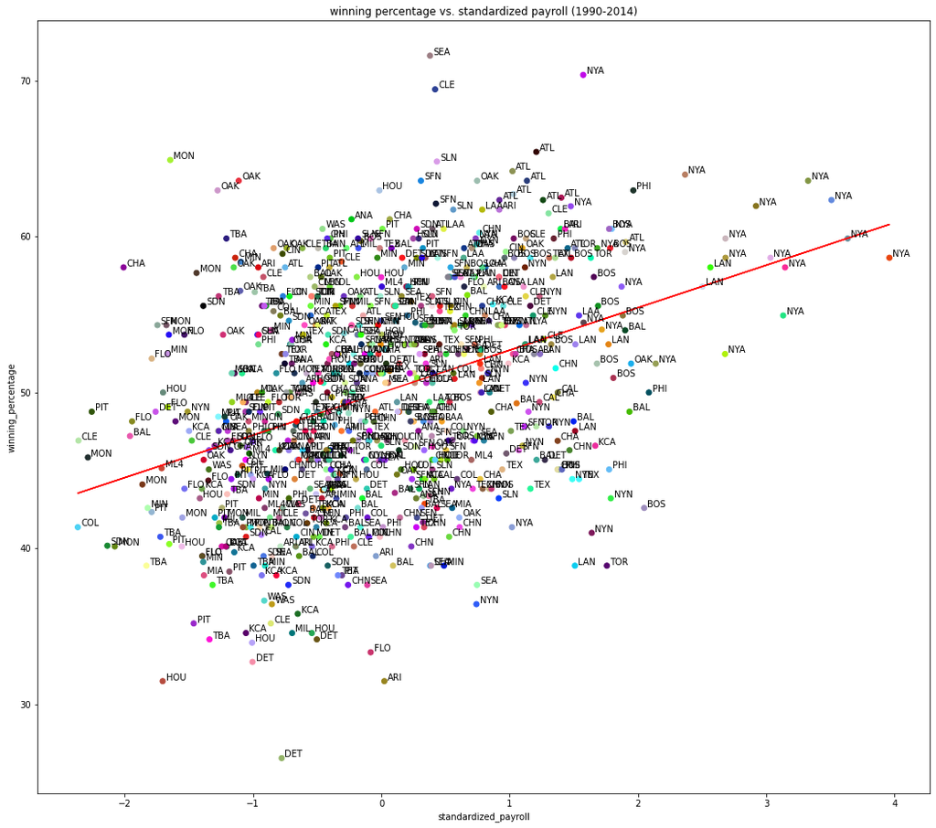

```python
# Re-index the dataframe
std_payroll.index = np.arange(0, len(std_payroll))

# Store the data columns needed for the scatter plot into variables for convention
std_payroll_plot = std_payroll["standardized_payroll"]
winning_percentage_plot = std_payroll["winning_percentage"]
teamID = std_payroll["teamID"]

# Set the display size of the scatter plot
plt.figure(figsize=(18,16))

# Scatter plot with winning percentage (y-axis) vs. standardized payroll (x-axis) from year 1990-2014
plt.scatter(std_payroll_plot, winning_percentage_plot, c=np.random.rand(len(std_payroll_plot),3))

# Add appropriate labels and title to the plot
plt.title("winning percentage vs. standardized payroll (1990-2014)")
plt.xlabel("standardized_payroll")
plt.ylabel("winning_percentage")

# Label the points in the scatter plot with teamID
for i, team in enumerate (teamID):
    plt.text(std_payroll_plot[i]+0.025, winning_percentage_plot[i]+0.07, team)

# Obtain m (slope) and b (intercept) of linear regression line
m, b = np.polyfit(std_payroll_plot, winning_percentage_plot, 1)

# Use red as color for plotting the regression line
plt.plot(std_payroll_plot, m*std_payroll_plot+b, c="red")
```

# #3. Spending efficiency

# Problem 8: Create a new field to compute each team's spending effiency and make a line plot with year on the x-axis and efficiency on the y-axis.

```
teamID
ATL    AxesSubplot(0.125,0.125;0.775x0.755)
BOS    AxesSubplot(0.125,0.125;0.775x0.755)
NYA    AxesSubplot(0.125,0.125;0.775x0.755)
OAK    AxesSubplot(0.125,0.125;0.775x0.755)
TBA    AxesSubplot(0.125,0.125;0.775x0.755)
Name: efficiency, dtype: object
```

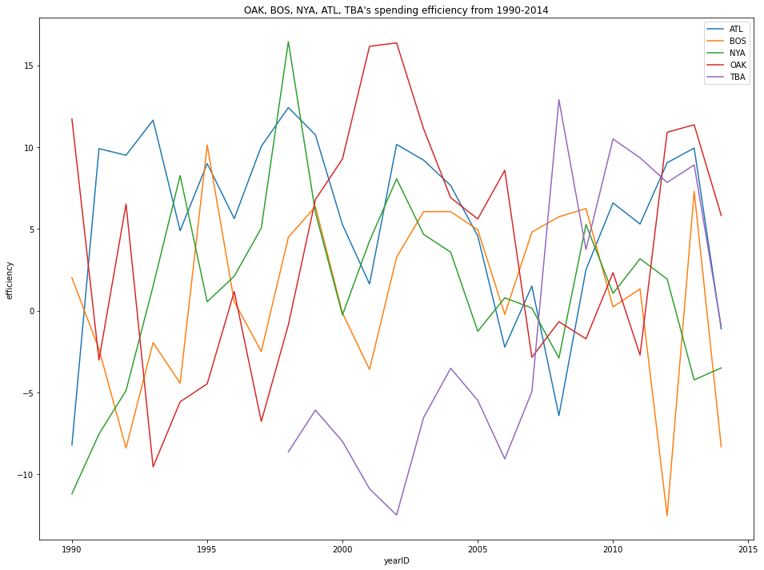

```python
# Create a copy of the dataframe
payroll_efficiency = std_payroll

# Using the calculated expected winning percentage to calculate efficiency with the formula and create a new field of spending efficiency in the dataframe
payroll_efficiency["efficiency"] = payroll_efficiency["winning_percentage"] - (50 + 2.5 * payroll_efficiency["standardized_payroll"])

# Extract the data with the desired set of teams only
payroll_efficiency = payroll_efficiency[payroll_efficiency["teamID"].apply(lambda x: x == "OAK" or x == "BOS" or x == "NYA" or x == "ATL" or x == "TBA")]

# Drop the unneeded columns for the plot
payroll_efficiency = payroll_efficiency.drop(columns={"total_payroll", "winning_percentage", "average_payroll", "std_by_year", "standardized_payroll", "year_bins"})

# Set the yearID as the index of the dataframe
payroll_efficiency = payroll_efficiency.set_index("yearID")

# Make the line plot for each team from 1990-2014 with efficiency on the y-axis and yearID on the x-axis
payroll_efficiency.groupby(["teamID"])["efficiency"].plot(xlabel="yearID", ylabel="efficiency", figsize=(16,12),
                                                          title="OAK, BOS, NYA, ATL, TBA's spending efficiency from 1990-2014", legend=True)
```

# Question 4: What can you learn from this plot compared to the set of plots you looked at in Question 2 and 3? How good was Oakland's efficiency during the Moneyball period?

```
This plot is a much better visualization to anaylze the correlation between the teams' winning percentage and total_payroll. We can easily see each team's spending efficiency over the time periods. The previous scatter plots did not provide a standard for whether the teams' payroll and winning percentage are matched proportionally. We can see that the Oakland's efficiency over the Moneyball periods is magnificent. For example, their spending efficiency from 2000 to 2005 is as high as NYA's spending efficiency from 1995 to 2000. However, Oaklands spends way less money than NYA on average, so their payroll spending is extremly efficient.
```